# Introduction to Numpy

Monte Lunacek

## What is `numpy`?

Provides `C`-compiled array-oriented computing in `Python`.

- **Efficient**
- **Foundational**
- Typed,in-memory
- Contigous and homeogenous

Usage

- Scientific data (weather data, satellite data)
- Image processing
- Time series
- Linear algebra

## Efficient computing

The `triad` memory bandwidth [stream test](http://www.cs.virginia.edu/stream/ref.html).

```python
import random

N = 100000
A = [0 for i in xrange(N)]
B = [1000.* random.random() for i in xrange(N)]
C = [1000.* random.random() for i in xrange(N)]
d = 0.1
```

```python
%%timeit
for i in xrange(N):
    A[i] = B[i] + d * C[i]
```

```
10 loops, best of 3: 34.6 ms per loop
```

## The `numpy` solution

```python
import numpy as np

a = np.array(A)
b = np.array(B)
c = np.array(C)
```

Using `numpy` matrix syntax.

```python
%%timeit
a = b + d*c
```

```
1000 loops, best of 3: 270 µs per loop
```

## Why is `numpy` faster?

`numpy`

- provides a **typed** data structure (`ndarray`)
- a set of **compiled functions** (`ufuncs`)

`python`

- Lists: heterogeneous, **dynamically** typed
- `for` loops are **interpreted**

## Intel `MKL` `BLAS` library

[figure not shown]

## Foundational stack

[figure not shown]

## Outline

Understand the **`ndarray`** data structure

Discuss **ufuncs**

- Array-oriented computing
- Avoid for loops
- Use fast algorithms

Quick note on **slicing** and `numpy` views.

**Broadcasting**

## The `ndarray` object

Arrays can be created from

- lists or tuples
- using functions
- reading data from files

```python
vector = np.array([1, 2, 3, 4, 5, 6, 7, 8, 9 ])
print vector
print type(vector)
```

```
[1 2 3 4 5 6 7 8 9]
<type 'numpy.ndarray'>
```

```python
M = np.array([ [1, 2, 3],[4, 5, 6], [7,8,9]], dtype=np.int32)
print M
print type(M)
```

```
[[1 2 3]
 [4 5 6]
 [7 8 9]]
<type 'numpy.ndarray'>
```

### Properties

[figure not shown]

```python
print vector.shape
print vector.size
print vector.dtype
```

```
(9,)
9
int64
```

```python
print vector.strides
print vector.ctypes.data
```

```
(8,)
64792416
```

### Properties

[figure not shown]

```python
print M.shape, M.size, M.dtype
```

```
(3, 3) 9 int32
```

```python
print M.strides, M.ctypes.data
```

```
(12, 4) 63343008
```

### Understanding layout and strides

```python
A = M.T
print M.shape, M.size, M.dtype
print A.shape, A.size, A.dtype
```

```
(3, 3) 9 int32
(3, 3) 9 int32
```

```python
print M.strides, M.flags.c_contiguous, M.flags.f_contiguous
print A.strides, A.flags.c_contiguous, A.flags.f_contiguous
```

```
(12, 4) True False
(4, 12) False True
```

[figure not shown]

### Views

```python
print M.ctypes.data, M.flags.owndata
print A.ctypes.data, A.flags.owndata
```

```
63343008 True
63343008 False
```

```python
B = A.reshape((A.size,))
print B.flags.owndata
print B
```

```
False
[1 4 7 2 5 8 3 6 9]
```

```python
print B.shape, B.strides
```

```
(9,) (4,)
```

### Using array-generating functions

For larger arrays it is inpractical to initialize the data manually

```python
print np.arange(1, 6, 0.55)
```

```
[ 1.    1.55  2.1   2.65  3.2   3.75  4.3   4.85  5.4   5.95]
```

```python
print np.linspace(0, 10, 5)
```

```
[  0.    2.5   5.    7.5  10. ]
```

```python
print np.zeros(4)
print np.ones((4,3))
```

```
[ 0.  0.  0.  0.]
[[ 1.  1.  1.]
 [ 1.  1.  1.]
 [ 1.  1.  1.]
 [ 1.  1.  1.]]
```

```python
print np.diag([1, 2, 3])
```

```
[[1 0 0]
 [0 2 0]
 [0 0 3]]
```

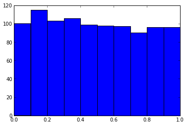

```python
%matplotlib inline
import matplotlib.pyplot as plt

plt.show(plt.hist(np.random.rand(1000)))
```

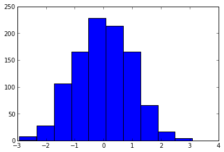

```python
plt.show(plt.hist(np.random.normal(0,1,1000)))
```

## Using `ufuncs`

- Operate on the elements of one or more `ndarray`
- Call optimized c loops based on the `dtype`

### Unary functions

Several built-in functions that takes one argument:

```
    abs, fabs, sqrt, exp, square, log, ceil, floor
```

For example

```python
x = np.arange(-5.,5.)
print np.square(x)
```

```
[ 25.  16.   9.   4.   1.   0.   1.   4.   9.  16.]
```

```python
print np.abs(x)
```

```
[ 5.  4.  3.  2.  1.  0.  1.  2.  3.  4.]
```

### Binary functions

```
    add, subtract, multiply, divide, power, maximum, minimum, greater, less
```

For example

```python
y = np.square(x)
z = np.add(x,y)
print z
print x + y
```

```
[ 20.  12.   6.   2.   0.   0.   2.   6.  12.  20.]
[ 20.  12.   6.   2.   0.   0.   2.   6.  12.  20.]
```

### Aggregates

```
    sum, mean, std, var, min, max, argmin, argmax, cumsum, cumprod
```

Examples

```python
print z.sum(), np.sum(z)
```

```
80.0 80.0
```

```python
x = np.random.rand(8).reshape((2,4))
print x.shape
```

```
(2, 4)
```

```python
x.sum(axis=0) # sum the columns
```

```
array([ 0.9365839 ,  1.61373389,  1.30096846,  0.24923567])
```

```python
x.sum(1) # sum the rows
```

```
array([ 2.48967844,  1.61084348])
```

### The `accumulate` methods

```python
np.add.accumulate(x)
```

[output not shown]

```python
np.cumsum(x)
```

[output not shown]

```python
np.*.accumulate?
```

### Linear algebra

```
    dot, inv, diag, trace, eig, det, qr, svd, solve
```

Example matrix multiply

```python
x = np.random.rand(8).reshape((2,4))
b = np.dot(x,x.T)
print b
```

```
[[ 0.28118576  0.66189804]
 [ 0.66189804  1.57615403]]
```

## Indexing and slicing

- Index slicing is the technical name for the syntax

  ```
    container[lower:upper:step]
  ```

  to extract part of an array.
- We can omit any of the three parameters

  ```
    lower:upper:step
  ```

### Examples

```python
x = np.arange(1, 20, 1)
print x
```

```
[ 1  2  3  4  5  6  7  8  9 10 11 12 13 14 15 16 17 18 19]
```

```python
print x[0:10:1]
```

```
[ 1  2  3  4  5  6  7  8  9 10]
```

```python
print x[:10]
```

```
[ 1  2  3  4  5  6  7  8  9 10]
```

```python
print x[:10:2]
```

```
[1 3 5 7 9]
```

## 2D slicing

```python
M = np.array([ [1, 2, 3],[4, 5, 6], [7,8,9]])
```

[figure not shown]

```python
print M[0:2]
```

```
[[1 2 3]
 [4 5 6]]
```

```python
print M[:,0:2]
```

```
[[1 2]
 [4 5]
 [7 8]]
```

```python
M = np.array(np.arange(1,17)).reshape((4,4))
print M
```

```
[[ 1  2  3  4]
 [ 5  6  7  8]
 [ 9 10 11 12]
 [13 14 15 16]]
```

```python
print M[::2, ::2]
```

```
[[ 1  3]
 [ 9 11]]
```

[figure not shown]

### Filtering

```python
print x > 10
```

```
[False False False False False False False False False False  True  True
  True  True  True  True  True  True  True]
```

```python
y = x[x>10]
print y
```

```
[11 12 13 14 15 16 17 18 19]
```

```python
mask = (5 < x) * (x < 10)
print mask
```

```
[False False False False False  True  True  True  True False False False
 False False False False False False False]
```

```python
print x[mask]
```

```
[6 7 8 9]
```

## Broadcasting

Arithmetic between `array`s of different, but compatible, shapes.

```python
print np.arange(5) + 1
```

```
[1 2 3 4 5]
```

[figure not shown]

```python
A = np.arange(8).reshape(4,2)
B = np.arange(2)

print A.shape, B.shape
```

```
(4, 2) (2,)
```

```python
A + B
```

```
array([[0, 2],
       [2, 4],
       [4, 6],
       [6, 8]])
```

[figure not shown]

### Example

Find the distance from the mean of the set to every point?

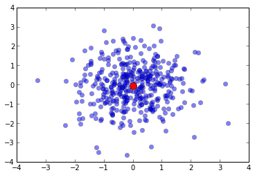

```python
a = np.random.randn(400,2)
m = a.mean(0)
plt.plot(a[:,0], a[:,1], 'o', markersize=6, alpha=0.5)
plt.plot(m[0], m[1], 'ro', markersize=10)
plt.show()
```

Euclidean distance

$$d = \sqrt{ \sum (x_i - y_i)^2 }$$

```python
sq = np.square(a - m)
print sq.shape, a.shape, m.shape
```

```
(400, 2) (400, 2) (2,)
```

```python
ssq = sq.sum(axis=1)
print ssq.shape
```

```
(400,)
```

Now take the `sqrt`.

```python
dist = np.sqrt(ssq)
print dist.shape
```

```
(400,)
```

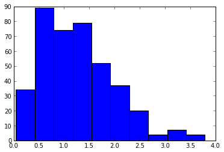

```python
plt.show(plt.hist(dist))
```

```python
print a.mean()
```

```
-0.0224118480525
```

```python
a.shape
```

```
(400, 2)
```

```python
a.mean(0).shape
```

```
(2,)
```

```python
a.mean(1).shape
```

```
(400,)
```